# Applied Logistic Regression. Homework 6

## Exercise One

For this exercise, you will use the ICU dataset (this is the same data we used in weeks 1 through 3). You can download the icu.dta Stata file, or you can also access the data through this CSV file.

From the ICU data, use as the outcome variable vital status (STA) and CPR prior to ICU admission (CPR) as a covariate.

```r
ICU <- read.delim("C:/Users/Karmen/Desktop/All Things Coursera/current/Applied Logistic Regression/1.week 1/ICU/ICU.txt")
str(ICU)
```

```
## 'data.frame':    200 obs. of  21 variables:
##  $ ID    : int  4 8 12 14 27 28 32 38 40 41 ...
##  $ STA   : int  1 0 0 0 1 0 0 0 0 0 ...
##  $ AGE   : int  87 27 59 77 76 54 87 69 63 30 ...
##  $ GENDER: int  1 1 0 0 1 0 1 0 0 1 ...
##  $ RACE  : int  1 1 1 1 1 1 1 1 1 1 ...
##  $ SER   : int  1 0 0 1 1 0 1 0 1 0 ...
##  $ CAN   : int  0 0 0 0 0 0 0 0 0 0 ...
##  $ CRN   : int  0 0 0 0 0 0 0 0 0 0 ...
##  $ INF   : int  1 1 0 0 1 1 1 1 0 0 ...
##  $ CPR   : int  0 0 0 0 0 0 0 0 0 0 ...
##  $ SYS   : int  80 142 112 100 128 142 110 110 104 144 ...
##  $ HRA   : int  96 88 80 70 90 103 154 132 66 110 ...
##  $ PRE   : int  0 0 1 0 1 0 1 0 0 0 ...
##  $ TYP   : int  1 1 1 0 1 1 1 1 0 1 ...
##  $ FRA   : int  1 0 0 0 0 1 0 0 0 0 ...
##  $ PO2   : int  1 0 0 0 0 0 0 1 0 0 ...
##  $ PH    : int  1 0 0 0 0 0 0 0 0 0 ...
##  $ PCO   : int  1 0 0 0 0 0 0 0 0 0 ...
##  $ BIC   : int  0 0 0 0 0 0 0 1 0 0 ...
##  $ CRE   : int  0 0 0 0 0 0 0 0 0 0 ...
##  $ LOC   : int  0 0 0 0 0 0 0 0 0 0 ...
```

Complete the following:

**a) Demonstrate that the value of the log-odds ratio obtained from the cross-classification of STA by CPR is identical to the estimated slope coefficient from the logistic regression of STA on CPR. Verify that the estimated standard error of the estimated slope coefficient for CPR obtained from the logistic regression package is identical to the square root of the sum of the inverse of the cell frequencies from the cross-classification of STA by CPR. Use either set of computations to obtain 95% CI for the odds ratio. What aspect concerning the coding of the variable CPR makes the calculations for the two methods equivalent?**

```r
table(ICU$STA)
```

```
##
##   0   1
## 160  40
```

```r
table(ICU$STA, ICU$CPR)
```

```
##
##       0   1
##   0 154   6
##   1  33   7
```

To calculate odds ratio of survival for those patients who received cardio-pulmonary resuscitation prior to ICU admission compared to those who haven’t, we can use the $2 \times 2$ table: $\begin{array}{|c|c|c|} \hline \text{} & \text{CPR = 0 = No} & \text{CPR = 1 = Yes} \\ \hline \text{STA=0=Died} & 154 & 6 \\ \hline \text{STA=1 Lived} & 33 & 7 \\ \hline \end{array}$

$\widehat{OR}(STA, CPR) = \frac{\frac{Died\ and\ No\ CPR}{Died\ and\ Yes\ CPR}}{\frac{Lived\ and\ No\ CPR}{Lived\ and\ Yes\ CPR}}$ $\widehat{OR}(STA, CPR) = \frac{Died\ and\ No\ CPR)}{(Died\ and\ Yes\ CPR)} \cdot \frac{(Lived\ and\ Yes\ CPR)}{(Lived\ and\ No\ CPR)}$ $\widehat{OR}(STA, CPR) = \frac{154}{6} \cdot \frac{7}{33} = 5.44$ It turns out that odds for survival are about 5.4 times greater in those who had CPR prior to admission to intensive care unit than those who hadn’t. To fit a logistic regression model of STA on CPR

```r
logfit1 <- glm(STA ~ CPR, data = ICU, family = binomial(link = "logit"))
(coefs <- summary(logfit1)$coefficients)
```

```
##              Estimate Std. Error   z value     Pr(>|z|)
## (Intercept) -1.540445  0.1918242 -8.030503 9.707395e-16
## CPR          1.694596  0.5884899  2.879566 3.982224e-03
```

To obtain odds ratio estimate for CPR we need to exponentiate coefficient for CPR

```r
(ORcpr <- exp(logfit1$coefficients[2]))
```

```
##      CPR
## 5.444444
```

```r
log(ORcpr)
```

```
##      CPR
## 1.694596
```

**b)For purposes of illustration, use a data transformation statement to recode, for this problem only, the variable CPR as follows: 4 = no and 2 = yes. Perform the logistic regression of STA on CPR (recoded). Demonstrate how the calculation of the logit difference of CPR = yes versus CPR = no is equivalent to the value of the log-odds ratio obtained in exercise 1-a. Use the results from the logistic regression to obtain the 95% CI for the odds ratio and verify that they are the same limits as obtained in Exercise 1-a.**

```r
ICU$CPRrecoded <- ifelse(ICU$CPR == 0, 4, 2)
head(ICU$CPRrecoded,40)
```

```
##  [1] 4 4 4 4 4 4 4 4 4 4 4 4 4 4 4 4 4 4 4 4 4 4 4 4 2 4 4 4 4 4 4 4 4 4 4
## [36] 4 4 4 4 4
```

```r
head(ICU$CPR, 40)
```

```
##  [1] 0 0 0 0 0 0 0 0 0 0 0 0 0 0 0 0 0 0 0 0 0 0 0 0 1 0 0 0 0 0 0 0 0 0 0
## [36] 0 0 0 0 0
```

```r
logit.recoded <- glm(STA ~ CPRrecoded, data = ICU, family = binomial(link = "logit"))
(summ.r <- summary(logit.recoded))
```

```
##
## Call:
## glm(formula = STA ~ CPRrecoded, family = binomial(link = "logit"),
##     data = ICU)
##
## Deviance Residuals:
##     Min       1Q   Median       3Q      Max
## -1.2435  -0.6231  -0.6231  -0.6231   1.8626
##
## Coefficients:
##             Estimate Std. Error z value Pr(>|z|)
## (Intercept)   1.8487     1.1291   1.637  0.10156
## CPRrecoded   -0.8473     0.2942  -2.880  0.00398 **
## ---
## Signif. codes:  0 '***' 0.001 '**' 0.01 '*' 0.05 '.' 0.1 ' ' 1
##
## (Dispersion parameter for binomial family taken to be 1)
##
##     Null deviance: 200.16  on 199  degrees of freedom
## Residual deviance: 192.23  on 198  degrees of freedom
## AIC: 196.23
##
## Number of Fisher Scoring iterations: 4
```

```r
predYes <-predict(logit.recoded, newdata = data.frame(CPRrecoded = 2))
predNo <- predict(logit.recoded, newdata = data.frame(CPRrecoded = 4))

(diff <- predYes - predNo)
```

```
##        1
## 1.694596
```

```r
coefs
```

```
##              Estimate Std. Error   z value     Pr(>|z|)
## (Intercept) -1.540445  0.1918242 -8.030503 9.707395e-16
## CPR          1.694596  0.5884899  2.879566 3.982224e-03
```

```r
log(ORcpr);diff
```

```
##      CPR
## 1.694596
```

```
##        1
## 1.694596
```

**c) Consider the ICU data and use as the outcome variable vital status (STA) and race (RACE) as a covariate. Prepare a table showing the coding of the two design variables for RACE using the value RACE = 1, white, as the reference group. Show that the estimated log-odds ratios obtained from the cross-classification of STA by RACE, using RACE = 1 as the reference group, are identical to estimated slope coefficients for the two design variables from the logistic regression of STA on RACE. Verify that the estimated standard errors of the estimated slope coefficients for the two design variables for RACE are identical to the square root of the sum of the inverse of the cell frequencies from the cross-classification of STA by RACE used to calculate the odds ratio. Use either set of computations to compute the 95% CI for the odds ratios.**

```r
ICU$RACE <- factor(ICU$RACE, levels = c(1,2,3), labels <- c("White", "Black", "Other"))
logfit3 <- glm(STA ~ RACE, data = ICU, family = binomial(link = "logit"))
(coefs3 <- summary(logfit3)$coefficients)
```

```
##                Estimate Std. Error     z value     Pr(>|z|)
## (Intercept) -1.31633577  0.1851308 -7.11030229 1.157891e-12
## RACEBlack   -1.32272156  1.0515203 -1.25791343 2.084231e-01
## RACEOther   -0.06995859  0.8119565 -0.08616051 9.313388e-01
```

```r
contrasts(ICU$RACE)
```

```
##       Black Other
## White     0     0
## Black     1     0
## Other     0     1
```

```r
table(ICU$RACE, ICU$STA)
```

```
##
##           0   1
##   White 138  37
##   Black  14   1
##   Other   8   2
```

```r
(OR.Black <- (138 * 1)/(14 *37))
```

```
## [1] 0.2664093
```

```r
(beta.RACEBlack <- log(OR.Black)); coefs3[2,1]
```

```
## [1] -1.322722
```

```
## [1] -1.322722
```

```r
(OR.Other <- (138*2)/(37 * 8))
```

```
## [1] 0.9324324
```

```r
(beta.RACEOther <- log(OR.Other)); coefs3[3,1]
```

```
## [1] -0.06995859
```

```
## [1] -0.06995859
```

Slopes match.

```r
(VAR.RACEBlack <- (1/138)+(1/37)+ (1/14)+(1/1))
```

```
## [1] 1.105702
```

```r
(SE.RACEBlack <- sqrt(VAR.RACEBlack))
```

```
## [1] 1.051524
```

```r
coefs3[2,2]
```

```
## [1] 1.05152
```

```r
(VAR.RACEOther <- (1/138)+(1/37)+ (1/8)+(1/2))
```

```
## [1] 0.6592734
```

```r
(SE.RACEOther <- sqrt(VAR.RACEOther))
```

```
## [1] 0.8119565
```

```r
coefs3[3,2]
```

```
## [1] 0.8119565
```

Standard errors match.

```r
#95% Confidence interval for the odds ratios
(CI.Black <- beta.RACEBlack + c(-1,1) * qnorm(0.975) * SE.RACEBlack)
```

```
## [1] -3.3836700  0.7382269
```

```r
(CI.ORBlack <- exp(CI.Black))
```

```
## [1] 0.03392273 2.09222254
```

```r
(CI.Other <- beta.RACEOther + c(-1,1) * qnorm(0.975) * SE.RACEOther)
```

```
## [1] -1.661364  1.521447
```

```r
(CI.OROther <- exp(CI.Other))
```

```
## [1] 0.1898798 4.5788458
```

**d) Create design variables for RACE using the method typically employed in ANOVA. Perform the logistic regression of STA on RACE. Show by calculation that the estimated logit differences of RACE = 2 versus RACE = 1 and RACE = 3 versus RACE = 1 are equivalent to the values of the log-odds ratio obtained in problem 1(c). Use the results of the logistic regression to obtain the 95% CI for the odds ratios and verify that they are the same limits as obtained in Exercise 1(c). Note that the estimated covariance matrix for the estimated coefficients is needed to obtain the estimated variances of the logit differences.**

```r
#assigning new coding for the dummy variables with contrasts() function
(recode <- rbind(rep(-1,2), diag(1,2)))
```

```
##      [,1] [,2]
## [1,]   -1   -1
## [2,]    1    0
## [3,]    0    1
```

```r
(contrasts(ICU$RACE) <- recode)
```

```
##      [,1] [,2]
## [1,]   -1   -1
## [2,]    1    0
## [3,]    0    1
```

```r
#building model
logfit.recode <- glm(STA ~ RACE, data = ICU, family = binomial(link = "logit"))
(summ.recode <- summary(logfit.recode))
```

```
##
## Call:
## glm(formula = STA ~ RACE, family = binomial(link = "logit"),
##     data = ICU)
##
## Deviance Residuals:
##     Min       1Q   Median       3Q      Max
## -0.6893  -0.6893  -0.6893  -0.3715   2.3272
##
## Coefficients:
##             Estimate Std. Error z value Pr(>|z|)
## (Intercept)  -1.7806     0.4385  -4.060  4.9e-05 ***
## RACE1        -0.8585     0.7412  -1.158    0.247
## RACE2         0.3943     0.6330   0.623    0.533
## ---
## Signif. codes:  0 '***' 0.001 '**' 0.01 '*' 0.05 '.' 0.1 ' ' 1
##
## (Dispersion parameter for binomial family taken to be 1)
##
##     Null deviance: 200.16  on 199  degrees of freedom
## Residual deviance: 197.90  on 197  degrees of freedom
## AIC: 203.9
##
## Number of Fisher Scoring iterations: 5
```

```r
#the default coding
coefs3
```

```
##                Estimate Std. Error     z value     Pr(>|z|)
## (Intercept) -1.31633577  0.1851308 -7.11030229 1.157891e-12
## RACEBlack   -1.32272156  1.0515203 -1.25791343 2.084231e-01
## RACEOther   -0.06995859  0.8119565 -0.08616051 9.313388e-01
```

```r
(race.W <- predict(logfit.recode, newdata = data.frame(RACE = "White")))
```

```
##         1
## -1.316336
```

```r
(race.B <- predict(logfit.recode, newdata = data.frame(RACE = "Black")))
```

```
##         1
## -2.639057
```

```r
(diff1 <- race.B - race.W)
```

```
##         1
## -1.322722
```

```r
#values of the log-odds ratio obtained in problem 1(c):
(OR.Black <- (138 * 1)/(14 *37))
```

```
## [1] 0.2664093
```

```r
(beta.RACEBlack <- log(OR.Black)); coefs3[2,1]
```

```
## [1] -1.322722
```

```
## [1] -1.322722
```

```r
(race.O <- predict(logfit.recode, newdata = data.frame(RACE = "Other")))
```

```
##         1
## -1.386294
```

```r
(diff2 <- race.O - race.W)
```

```
##           1
## -0.06995859
```

```r
#values of the log-odds ratio obtained in problem 1(c):
(OR.Other <- (138*2)/(37 * 8))
```

```
## [1] 0.9324324
```

```r
(beta.RACEOther <- log(OR.Other)); coefs3[3,1]
```

```
## [1] -0.06995859
```

```
## [1] -0.06995859
```

The numbers match.

$diff1 = logit(RACE = Black) - logit(RACE = White)$ $diff1 = \beta_0 + \beta_1*(D_1=1) + \beta_2*(D_2=0) - [\beta_0 + \beta_1*(D_1=-1) + \beta_2 *(D_2=-1) ]$ $diff1 = 2*\beta_1 + \beta_2$ Then $Var(diff1) = (2*\beta_1 + \beta_2)(2*\beta_1 + \beta_2)$ $Var(diff1) = 4*\beta_1^2 + \beta_1^2 + 4*\beta_1*\beta_2$ $Var(diff1) = 4*Var(\beta_1) + Var(\beta_1) + 4*Cov(\beta_1*\beta_2)$

```r
#95% confidence interval for the odds ratios
(coefs <- summ.recode$coef)
```

```
##               Estimate Std. Error    z value     Pr(>|z|)
## (Intercept) -1.7805625  0.4385196 -4.0603942 4.898993e-05
## RACE1       -0.8584948  0.7412422 -1.1581840 2.467890e-01
## RACE2        0.3942681  0.6329556  0.6229001 5.333501e-01
```

```r
2*coefs[2,1] + coefs[3,1]; diff1
```

```
## [1] -1.322722
```

```
##         1
## -1.322722
```

```r
(vcov.r <- vcov(logfit.recode))
```

```
##             (Intercept)      RACE1       RACE2
## (Intercept)  0.19229945  0.1648411  0.01603389
## RACE1        0.16484109  0.5494400 -0.37317442
## RACE2        0.01603389 -0.3731744  0.40063278
```

```r
(Var.diff1 <- 4*vcov.r[2,2] + vcov.r[3,3] + 4*vcov.r[2,3])
```

```
## [1] 1.105695
```

```r
(SE.diff1 <- sqrt(Var.diff1))
```

```
## [1] 1.05152
```

```r
(CI.OR.B <- diff1 + c(-1,1) * qnorm(0.975) * SE.diff1)
```

```
## [1] -3.3836635  0.7382204
```

```r
(exp(CI.OR.B))
```

```
## [1] 0.03392295 2.09220897
```

This CI matched the one obtained earlier.

$diff2 = logit(RACE = Other) - logit(RACE = White)$ $diff2 = \beta_0 + \beta_1(D_1 = 0) + \beta_2(D_2=1) - [\beta_0 + \beta_1(D_1 = (-1)) + \beta_2(D_2 = (-1)]$ $diff2 = \beta_1 + 2*\beta_2$ $Var(diff2) = (\beta_1 + 2*\beta_2) \cdot (\beta_1 + 2*\beta_2)$ $Var(diff2) = \beta_1^2 + 4*\beta_1*\beta_2 + 4*\beta_2^2$ $Var(diff2) = Var(\beta_1) + 4*Cov(\beta_1, \beta_2) + 4*Var(\beta_2)$

```r
(Var.diff2 <- vcov.r[2,2] + 4 * vcov.r[3,2] + 4 * vcov.r[3,3])
```

```
## [1] 0.6592734
```

```r
(SE.diff2 <- sqrt(Var.diff2))
```

```
## [1] 0.8119565
```

```r
SE.RACEOther
```

```
## [1] 0.8119565
```

```r
#calculating confidence interval
(CI.OR.O <- diff2 + c(-1,1) * qnorm(0.975) * SE.diff2)
```

```
## [1] -1.661364  1.521447
```

```r
CI.Other
```

```
## [1] -1.661364  1.521447
```

```r
exp(CI.OR.O)
```

```
## [1] 0.1898798 4.5788458
```

```r
CI.OROther
```

```
## [1] 0.1898798 4.5788458
```

This CI mathed the one (`CI.Other`) obtained earlier.

**e) Consider the logistic regression of STA on CRN and AGE. Consider CRN to be the risk factor and show that AGE is a confounder of the association of CRN with STA. Addition of the interaction of AGE by CRN presents an interesting modeling dilemma. Examine the main effects only and interaction models graphically. Using the graphical results and any significance tests you feel are needed, select the best model (main effects or interaction) and justify your choice. Estimate relevant odds ratios. Repeat this analysis of confounding and interaction for a model that includes CPR as the risk factor and AGE as the potential confounding variable.**

```r
logfit.renal <- glm(STA ~ CRN, data = ICU, family = binomial(link = "logit"))
logfit.renal.age <- glm(STA ~ CRN + AGE, data = ICU, family = binomial(link = "logit"))

(coefs.renal <- summary(logfit.renal)$coefficients)
```

```
##              Estimate Std. Error   z value     Pr(>|z|)
## (Intercept) -1.538210  0.1948369 -7.894863 2.906348e-15
## CRN          1.219757  0.5038556  2.420846 1.548445e-02
```

```r
(coefs.renal.age <- summary(logfit.renal.age)$coefficients)
```

```
##                Estimate Std. Error   z value     Pr(>|z|)
## (Intercept) -3.02987537 0.69997728 -4.328534 1.501053e-05
## CRN          1.01985643 0.51492075  1.980609 4.763519e-02
## AGE          0.02499148 0.01072279  2.330688 1.976981e-02
```

```r
(change.beta1 <- (coefs.renal.age[2,1] - coefs.renal[2,1])/coefs.renal[2,1])
```

```
## [1] -0.1638853
```

$\beta_1$, the coefficient for CRN has decreased by 16.39 % when AGE was included in the model. This suggests that AGE could be a confounder in logistic regression of STA on CRN.

```r
logfit.ren.interaction <- glm(STA ~ CRN * AGE, data = ICU, family = binomial(link = "logit"))
(coefs.ren.interaction <- summary(logfit.ren.interaction)$coefficients)
```

```
##                Estimate Std. Error   z value     Pr(>|z|)
## (Intercept) -3.29792710 0.77053440 -4.280052 1.868499e-05
## CRN          3.57310095 2.32226097  1.538630 1.238946e-01
## AGE          0.02924198 0.01172503  2.493978 1.263203e-02
## CRN:AGE     -0.03809248 0.03405789 -1.118463 2.633695e-01
```

```r
#to assess slope of the interaction term
(G.interaction <- logfit.renal.age$deviance - logfit.ren.interaction$deviance)
```

```
## [1] 1.242437
```

```r
(df.diff <- logfit.renal.age$df.residual - logfit.ren.interaction$df.residual)
```

```
## [1] 1
```

```r
(pValue <- pchisq(G.interaction, df = df.diff, lower.tail = FALSE))
```

```
## [1] 0.2650019
```

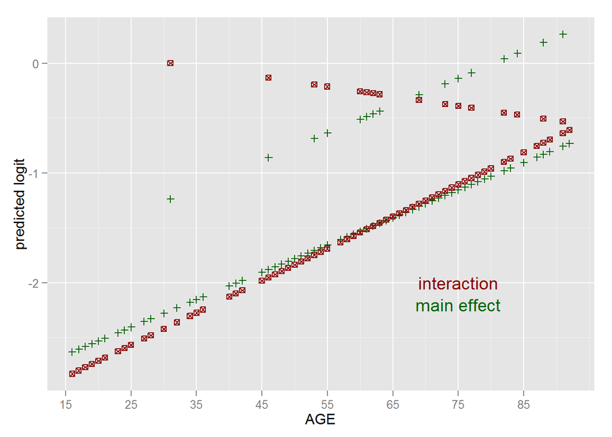

```r
library(ggplot2)

ggplot()  +
  geom_point(data = ICU, aes(x = AGE, y = predict(logfit.renal.age)), pch = 3, color = "darkgreen")  +
  geom_point(data = ICU, aes(x = AGE, y = predict(logfit.ren.interaction)), pch = 7, color = "darkred")  +
  scale_x_continuous(breaks = seq(15,90,10))  +
  ylab("predicted logit")  +
  annotate("text", x = 75, y = -2, label = "interaction", color = "darkred")  +
  annotate("text", x = 75, y = -2.2, label = "main effect", color = "darkgreen")
```

**Now, the CPR model:**

```r
logfit.cpr.main <- glm(STA ~ CPR + AGE, data = ICU, family = binomial(link = "logit"))
(coefs.main <- summary(logfit.cpr.main)$coefficients)
```

```
##                Estimate Std. Error   z value     Pr(>|z|)
## (Intercept) -3.35195550 0.74549946 -4.496255 6.916086e-06
## CPR          1.78409209 0.60729714  2.937758 3.305948e-03
## AGE          0.02960741 0.01114894  2.655627 7.916122e-03
```

```r
logfit.cpr.interaction <- glm(STA ~ CPR * AGE, data = ICU, family = binomial(link = "logit"))
(coefs.interaction <- summary(logfit.cpr.interaction)$coefficients)
```

```
##                Estimate Std. Error    z value     Pr(>|z|)
## (Intercept) -3.04195778 0.73568893 -4.1348424 3.551983e-05
## CPR         -3.72293544 4.21463805 -0.8833346 3.770555e-01
## AGE          0.02476654 0.01116633  2.2179663 2.655713e-02
## CPR:AGE      0.09418772 0.07080412  1.3302576 1.834334e-01
```

```r
(change.cpr <- (logfit1$coef[2] - coefs.main[2,1] )/logfit1$coef[2])
```

```
##         CPR
## -0.05281282
```

```r
#assessing the significance of the slope for interaction term
(G.cpr <- logfit.cpr.main$deviance - logfit.cpr.interaction$deviance)
```

```
## [1] 2.84303
```

```r
(df.cpr <- logfit.cpr.main$df.residual - logfit.cpr.interaction$df.residual)
```

```
## [1] 1
```

```r
(pVal.cpr <- pchisq(G.cpr, df = df.cpr, lower.tail = FALSE))
```

```
## [1] 0.09177102
```

p-value from likelihood ratio test of models with and without interaction suggests that AGE isn’t an effect modifier on relationship between risk factor CPR and outcome STA. We can make a graph:

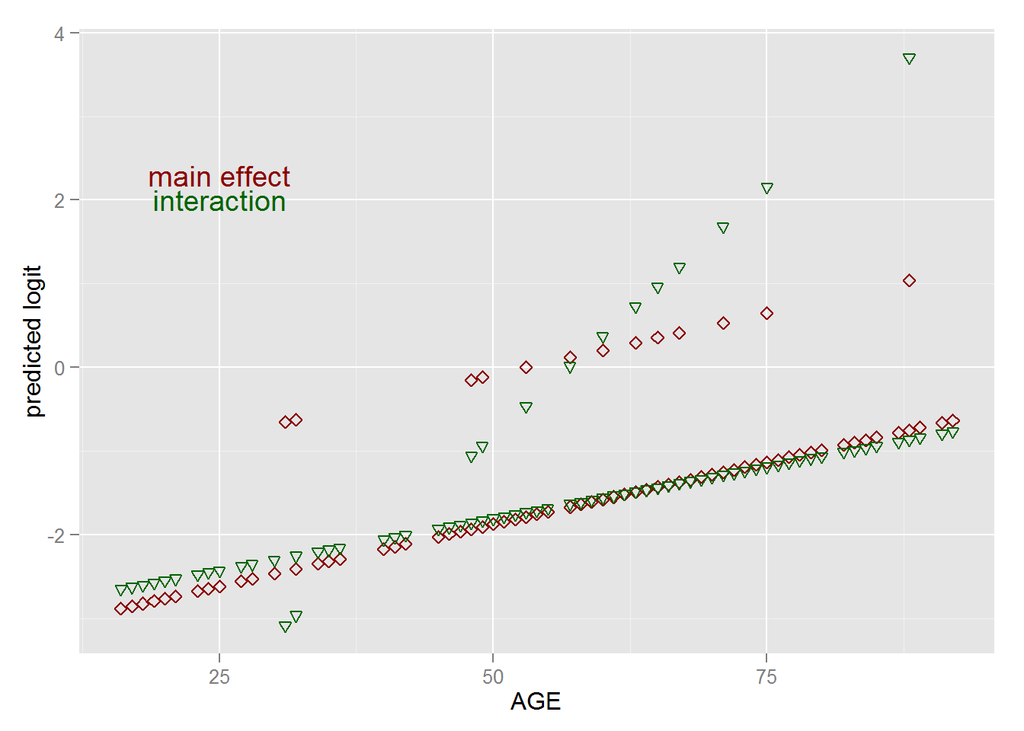

```r
ggplot()  +
  geom_point(data = ICU, aes(x = AGE, y = predict(logfit.cpr.main)), pch = 5, color = "darkred")  +
  geom_point(data = ICU, aes(x = AGE, y = predict(logfit.cpr.interaction)), pch = 6, color = "darkgreen")  +
  ylab("predicted logit")  +
  annotate("text", x = 25, y = 2.3, label = "main effect", color = "darkred")  +
  annotate("text", x = 25, y = 2, label = "interaction", color = "darkgreen")
```

It seems that the model with main effects only is the one to choose.

**f) Consider an analysis for confounding and interaction for the model with STA as the outcome, CAN as the risk factor, and TYP as the potential confounding variable. Perform this analysis using logistic regression modeling and Mantel-Haenszel analysis. Compare the results of the two approaches.**

```r
logfit.c.t <-glm(STA ~ CAN + TYP, data = ICU, family = binomial(link = "logit"))
(coefs.c.t <- summary(logfit.c.t)$coefficients)
```

```
##              Estimate Std. Error   z value     Pr(>|z|)
## (Intercept) -3.820209  0.8563555 -4.461008 8.157498e-06
## CAN          1.364004  0.7817448  1.744820 8.101621e-02
## TYP          2.709722  0.8598231  3.151488 1.624407e-03
```

```r
logfit.CAN <- glm(STA ~ CAN, data = ICU, family = binomial(link = "logit"))
(coefs.CAN <- summary(logfit.CAN)$coef)
```

```
##                  Estimate Std. Error       z value     Pr(>|z|)
## (Intercept) -1.386294e+00  0.1863390 -7.439638e+00 1.009615e-13
## CAN         -3.271025e-15  0.5892555 -5.551115e-15 1.000000e+00
```

```r
#assessing whether TYP is a confounder
(change.CAN <- (coefs.c.t[2] - coefs.CAN[2])/coefs.CAN[2])
```

```
## [1] -4.169958e+14
```

This would suggest that TYP is an important confounder. Now we’ll calculate Mantel-Haenszel estimator: it’s a pooled OR for OR’s for each stratum of covariate (TYP). Mantel-Haenszel estimator ($OR_{MH}$) is about equal to the exponentiated slope for the risk factor $e^{\beta_{CAN}}$ when the confounder (TYP) is included in the model.

```r
tbl <- with(ICU, table(STA, CAN, TYP))
tbl
```

```
## , , TYP = 0
##
##    CAN
## STA   0   1
##   0  37  14
##   1   1   1
##
## , , TYP = 1
##
##    CAN
## STA   0   1
##   0 107   2
##   1  35   3
```

```r
(MH <- mantelhaen.test(tbl, correct = FALSE))
```

```
##
##  Mantel-Haenszel chi-squared test without continuity correction
##
## data:  tbl
## Mantel-Haenszel X-squared = 3.4475, df = 1, p-value = 0.06335
## alternative hypothesis: true common odds ratio is not equal to 1
## 95 percent confidence interval:
##   0.8432041 17.9691213
## sample estimates:
## common odds ratio
##           3.89251
```

```r
names(MH)
```

```
## [1] "statistic"   "parameter"   "p.value"     "conf.int"    "estimate"
## [6] "null.value"  "alternative" "method"      "data.name"
```

```r
#compare OR calculated using estimate of beta for CAN and pooled Mantel-Haenszel estimator
exp(logfit.c.t$coef[2]); MH$estimate
```

```
##      CAN
## 3.911825
```

```
## common odds ratio
##           3.89251
```

The estimate of slope for $\beta_{CAN}$ when exponentiated yields odds ratio that is very similar to the one calculated by Mantel-Haenszel formula.

### Testing for homogeneity

First find logit-base estimator, a pooled OR: $\widehat{OR_i} = \frac{a_i \cdot d_i}{b_i \cdot c_i}$

```r
elective.0 <- ICU[ICU$TYP == 0, ]
emergency.1 <- ICU[ICU$TYP == 1, ]
(elective.tbl <-table(elective.0$STA, elective.0$CAN))
```

```
##
##      0  1
##   0 37 14
##   1  1  1
```

```r
(emergency.tbl <- with(emergency.1, table(STA,CAN)))
```

```
##    CAN
## STA   0   1
##   0 107   2
##   1  35   3
```

```r
(OR_zero <- (37*1)/(14*1))
```

```
## [1] 2.642857
```

```r
(OR_one <- (107*3)/(2*35))
```

```
## [1] 4.585714
```

Since logit-based estimator is a weighted average of the stratum specific odds ratios, we need to calculate weights, and for that we need variance of each of the stratum specific OR’s. $\widehat{Var}[ln(\widehat{OR_i})] = \frac{1}{a_i} +\frac{1}{b_i} +\frac{1}{c_i} + \frac{1}{d_i}$

```r
(Var.logOR.zero <-1/37 + 1/14 +1 +1)
```

```
## [1] 2.098456
```

```r
(Var.logOR.one <- 1/107 + 1/35 + 1/2 +1/3)
```

```
## [1] 0.8712506
```

Then weight for each stratum is inverse of its variance: $w_i = \frac{1}{\widehat{Var}[ln(\widehat{OR_i})]}$

The logit-based estimator is $OR_L = e^{\sum w_i ln(\widehat{OR_i})/\sum w_i}$

```r
(OR.L <- exp((Var.logOR.zero^(-1)*log(OR_zero) + Var.logOR.one^(-1)*log(OR_one))/(Var.logOR.zero^(-1) + Var.logOR.one^(-1))))  #3.90114
```

```
## [1] 3.90114
```

Now to test for homogeneity, we need to find squared deviance of each stratum specific log of odds ratio, then multiply it by its weight, and sum results for the strata. Such result follows $\chi^2$ distribution with degrees of freedom equal to the number of strata minus 1: $\chi_H^2 = \sum \{w_i[ln(OR_i) - ln(OR_L)]^2\}$

This $\sim \chi^2 (df = \# strata -1)$ Since this is a hypothesis test, we need to states hypotheses: $H_0: \widehat{OR_i}\ across\ strata\ are\ constant (homogenous)$ $H_A: \widehat{OR_i}\ across\ strata\ are\ heterogenous(not\ constant)$

```r
(chi_H <- (Var.logOR.zero^(-1)*(log(OR_zero) - log(OR.L))^2 + Var.logOR.one^(-1)*(log(OR_one) - log(OR.L))^2))
```

```
## [1] 0.1022643
```

```r
df.chi_H = 1

(pValue <- pchisq(chi_H, df = df.chi_H, lower.tail = FALSE))
```

```
## [1] 0.7491291
```

It turns out that p-value from this test is not significant to reject the null hypothesis. Hence we conclude that odds ratios of survival depending on whether a malignant neoplastic disease is part of the present problem across strata of type of admission into hospital, elective or emergency are homogenous. This was calculated by hand. However, we can obtain something similar to this using the output of our logistic regression. To test for homogeneity of odds ratios we buld model with interaction and compare it to model without interaction using likelihood ratio test

```r
#Building an interaction term
logfit.c.t.interaction <- glm(STA ~ CAN * TYP, data = ICU, family = binomial(link = "logit"))
(coefs.c.t.interaction <- summary(logfit.c.t.interaction))
```

```
##
## Call:
## glm(formula = STA ~ CAN * TYP, family = binomial(link = "logit"),
##     data = ICU)
##
## Deviance Residuals:
##     Min       1Q   Median       3Q      Max
## -1.3537  -0.7523  -0.7523  -0.2309   2.6972
##
## Coefficients:
##             Estimate Std. Error z value Pr(>|z|)
## (Intercept)  -3.6109     1.0134  -3.563 0.000366 ***
## CAN           0.9719     1.4486   0.671 0.502286
## TYP           2.4934     1.0320   2.416 0.015682 *
## CAN:TYP       0.5511     1.7233   0.320 0.749129
## ---
## Signif. codes:  0 '***' 0.001 '**' 0.01 '*' 0.05 '.' 0.1 ' ' 1
##
## (Dispersion parameter for binomial family taken to be 1)
##
##     Null deviance: 200.16  on 199  degrees of freedom
## Residual deviance: 181.92  on 196  degrees of freedom
## AIC: 189.92
##
## Number of Fisher Scoring iterations: 6
```

```r
(LR <- logfit.c.t$deviance - logfit.c.t.interaction$deviance)
```

```
## [1] 0.1021223
```

```r
(df.LR <- logfit.c.t$df.residual - logfit.c.t.interaction$df.residual)
```

```
## [1] 1
```

This value is very similar to the $\chi_H^2$ calculated above and have the same degrees of freedom. Since likelihood ratio follows $\chi^2$ distribution with degrees of freedom the difference in degrees of freedom of its respective models, we get p-value that is very similar to the one calculated by hand:

```r
(pVal.LR <- pchisq(LR, df.LR, lower.tail = FALSE))
```

```
## [1] 0.7492975
```

Likelihood ratio test tests for the significance of the slope of the interaction term here, since this is the thing where these two models differ. Since the p-value wasn’t less than customary $\alpha = 0.5$ we conclude that there isn’t much difference between models with and without interaction term, and the parsimonious model is better, we choose the model witmain effects only, no interacton term. That means that type of admission is a confounder but not an effect modifier.